# Introduction to t-SNE

Nurlan Dauletbayev

2023-12-21

This tutorial will compare the classical (metric) MDS (cMDS) with a popular non-linear dimensionality reduction algorithm “t-SNE”. “t-SNE” stands for “t-distributed Stochastic Neighbor Embedding”. A specific dataset called “Diabetes prediction dataset” (https://www.kaggle.com/datasets/iammustafatz/diabetes-prediction-dataset/data) will be used in this tutorial.

First, we will need to install two R packages:

```r
install.packages("Rtsne", repos = "http://cran.us.r-project.org")
```

```
##
##   There is a binary version available but the source version is later:
##       binary source needs_compilation
## Rtsne   0.16   0.17              TRUE
##
##   Binaries will be installed
```

```
##
##  C:\Users\ndaul\AppData\Local\Temp\Rtmpova25o\downloaded_packages
```

```r
library(Rtsne)
```

Next, we will import and check the dataset.

```r
myData <- read.csv(file.choose())
dim(myData)
```

```
## [1] 100000      9
```

```r
head(myData)
```

```
##   gender age hypertension heart_disease smoking_history   bmi HbA1c_level
## 1 Female  80            0             1               0 25.19         6.6
## 2 Female  54            0             0              99 27.32         6.6
## 3   Male  28            0             0               0 27.32         5.7
## 4 Female  36            0             0               4 23.45         5.0
## 5   Male  76            1             1               4 20.14         4.8
## 6 Female  20            0             0               0 27.32         6.6
##   blood_glucose_level diabetes
## 1                 140        0
## 2                  80        0
## 3                 158        0
## 4                 155        0
## 5                 155        0
## 6                  85        0
```

```r
tail(myData)
```

```
##        gender age hypertension heart_disease smoking_history   bmi HbA1c_level
## 99995  Female  36            0             0              99 24.60         4.8
## 99996  Female  80            0             0              99 27.32         6.2
## 99997  Female   2            0             0              99 17.37         6.5
## 99998    Male  66            0             0               1 27.83         5.7
## 99999  Female  24            0             0               0 35.42         4.0
## 100000 Female  57            0             0               4 22.43         6.6
##        blood_glucose_level diabetes
## 99995                  145        0
## 99996                   90        0
## 99997                  100        0
## 99998                  155        0
## 99999                  100        0
## 100000                  90        0
```

```r
lapply(myData, class)
```

```
## $gender
## [1] "character"
##
## $age
## [1] "numeric"
##
## $hypertension
## [1] "integer"
##
## $heart_disease
## [1] "integer"
##
## $smoking_history
## [1] "integer"
##
## $bmi
## [1] "numeric"
##
## $HbA1c_level
## [1] "numeric"
##
## $blood_glucose_level
## [1] "integer"
##
## $diabetes
## [1] "integer"
```

One categorical variable comprises character strings. This variable needs to be transformed as the “factor” type variable.

```r
myData$gender <- as.factor(myData$gender)
class(myData$gender)
```

```
## [1] "factor"
```

```r
levels(myData$gender)
```

```
## [1] "Female" "Male"   "Other"
```

```r
table(myData$gender)
```

```
##
## Female   Male  Other
##  58552  41430     18
```

Other categorical variables are presented as integer variables. Please note that for the purpose of this tutorial, the formerly character variable “smoking_history” has been modified to comprise the integers 0 - 4 and 99, with the latter replacing the original “No Info” category

```r
table(myData$hypertension)
```

```
##
##     0     1
## 92515  7485
```

```r
table(myData$heart_disease)
```

```
##
##     0     1
## 96058  3942
```

```r
table(myData$smoking_history)
```

```
##
##     0     1     2     3     4    99
## 35095  9352  4004  6447  9286 35816
```

```r
table(myData$diabetes)
```

```
##
##     0     1
## 91500  8500
```

We will start with subsetting 200 observations from this dataset. The subsetting is necessary because of the large size (100,000 observations) of the dataset. The original dataset will require extensive amounts of time if used in cMDS or t-SNE, and plotting of data points will appear smudged because of the sheer amount of data.

```r
myData.10001_10200 <- myData[c(10001 : 10200), ]
dim(myData.10001_10200)
```

```
## [1] 200   9
```

```r
head(myData.10001_10200)
```

```
##       gender age hypertension heart_disease smoking_history   bmi HbA1c_level
## 10001 Female  28            0             0               1 30.11         6.5
## 10002   Male  20            0             0              99 27.32         5.0
## 10003 Female  37            0             0               3 42.27         6.6
## 10004 Female  64            0             0               0 30.76         6.1
## 10005 Female   3            0             0              99 19.53         6.2
## 10006 Female  41            0             0               3 22.66         4.8
##       blood_glucose_level diabetes
## 10001                 200        0
## 10002                 159        0
## 10003                  90        0
## 10004                 158        0
## 10005                 140        0
## 10006                 126        0
```

```r
tail(myData.10001_10200)
```

```
##       gender age hypertension heart_disease smoking_history   bmi HbA1c_level
## 10195   Male  80            0             1               1 24.21         6.1
## 10196   Male  37            0             0               3 28.80         6.6
## 10197   Male  48            0             0               0 26.08         4.0
## 10198   Male  61            0             0               1 27.52         5.0
## 10199 Female  22            0             0               4 27.32         5.7
## 10200 Female  40            0             0               1 45.72         6.6
##       blood_glucose_level diabetes
## 10195                 130        0
## 10196                 100        0
## 10197                 158        0
## 10198                 130        0
## 10199                 158        0
## 10200                 140        0
```

This will characterize the new subset of 200 observations.

```r
table(myData.10001_10200$gender)
```

```
##
## Female   Male  Other
##    118     82      0
```

```r
table(myData.10001_10200$hypertension)
```

```
##
##   0   1
## 195   5
```

```r
table(myData.10001_10200$heart_disease)
```

```
##
##   0   1
## 198   2
```

```r
table(myData.10001_10200$smoking_history)
```

```
##
##  0  1  2  3  4 99
## 70 17  9 13 20 71
```

```r
table(myData.10001_10200$diabetes)
```

```
##
##   0   1
## 183  17
```

It will be helpful if we put the histograms of the two analyzed datasets side by side. This is achieved by introducing the function “par(mfrow = )” before the plot. Try to swich “2” and “1” in this function and see what happens with the plot layout.

Note: the number of “breaks” defines the number of bins by which the variable “age” will be presented in the histograms. Try to change this number and see what happens.

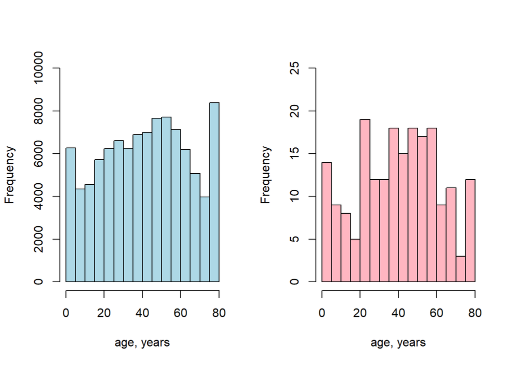

```r
par(mfrow = c(1, 2))
hist(myData$age, breaks = 25,
     ylim = c(0, 10000), col = "lightblue", main = "", xlab = "age, years")
hist(myData.10001_10200$age, breaks = 25, ylim = c(0, 25),
     col = "lightpink", main = "", xlab = "age, years")
```

Both histograms are not very similar, so another subset will be generated in the next section. For now, we will note that the subset of 200 observations does not adequately represent the original dataset. We will still transform it as a matrix, so we can use it later for comparison purposes.

```r
myMatrix_10001_10200 <- as.matrix(myData.10001_10200[, -1])
class(myMatrix_10001_10200)
```

```
## [1] "matrix" "array"
```

```r
dim(myMatrix_10001_10200)
```

```
## [1] 200   8
```

```r
head(myMatrix_10001_10200)
```

```
##       age hypertension heart_disease smoking_history   bmi HbA1c_level
## 10001  28            0             0               1 30.11         6.5
## 10002  20            0             0              99 27.32         5.0
## 10003  37            0             0               3 42.27         6.6
## 10004  64            0             0               0 30.76         6.1
## 10005   3            0             0              99 19.53         6.2
## 10006  41            0             0               3 22.66         4.8
##       blood_glucose_level diabetes
## 10001                 200        0
## 10002                 159        0
## 10003                  90        0
## 10004                 158        0
## 10005                 140        0
## 10006                 126        0
```

```r
tail(myMatrix_10001_10200)
```

```
##       age hypertension heart_disease smoking_history   bmi HbA1c_level
## 10195  80            0             1               1 24.21         6.1
## 10196  37            0             0               3 28.80         6.6
## 10197  48            0             0               0 26.08         4.0
## 10198  61            0             0               1 27.52         5.0
## 10199  22            0             0               4 27.32         5.7
## 10200  40            0             0               1 45.72         6.6
##       blood_glucose_level diabetes
## 10195                 130        0
## 10196                 100        0
## 10197                 158        0
## 10198                 130        0
## 10199                 158        0
## 10200                 140        0
```

We will now subset the first 2000 observations from the original dataset and verify the comparability of the new dataset with the original one.

```r
myData.1_2000 <- myData[c(1 : 2000), ]
dim(myData.1_2000)
```

```
## [1] 2000    9
```

```r
head(myData.1_2000)
```

```
##   gender age hypertension heart_disease smoking_history   bmi HbA1c_level
## 1 Female  80            0             1               0 25.19         6.6
## 2 Female  54            0             0              99 27.32         6.6
## 3   Male  28            0             0               0 27.32         5.7
## 4 Female  36            0             0               4 23.45         5.0
## 5   Male  76            1             1               4 20.14         4.8
## 6 Female  20            0             0               0 27.32         6.6
##   blood_glucose_level diabetes
## 1                 140        0
## 2                  80        0
## 3                 158        0
## 4                 155        0
## 5                 155        0
## 6                  85        0
```

```r
tail(myData.1_2000)
```

```
##      gender age hypertension heart_disease smoking_history   bmi HbA1c_level
## 1995   Male  28            0             0              99 37.75         3.5
## 1996 Female  53            1             0               0 26.39         5.8
## 1997 Female  43            0             0              99 27.32         5.7
## 1998 Female  80            0             0               0 27.32         6.6
## 1999   Male  71            0             0              99 27.32         6.0
## 2000   Male  60            0             0               1 29.62         3.5
##      blood_glucose_level diabetes
## 1995                 100        0
## 1996                 140        0
## 1997                 159        0
## 1998                 100        0
## 1999                 155        0
## 2000                 158        0
```

```r
table(myData.1_2000$gender)
```

```
##
## Female   Male  Other
##   1149    851      0
```

```r
table(myData.1_2000$hypertension)
```

```
##
##    0    1
## 1855  145
```

```r
table(myData.1_2000$heart_disease)
```

```
##
##    0    1
## 1924   76
```

```r
table(myData.1_2000$smoking_history)
```

```
##
##   0   1   2   3   4  99
## 716 186  85 124 170 719
```

```r
table(myData.1_2000$diabetes)
```

```
##
##    0    1
## 1819  181
```

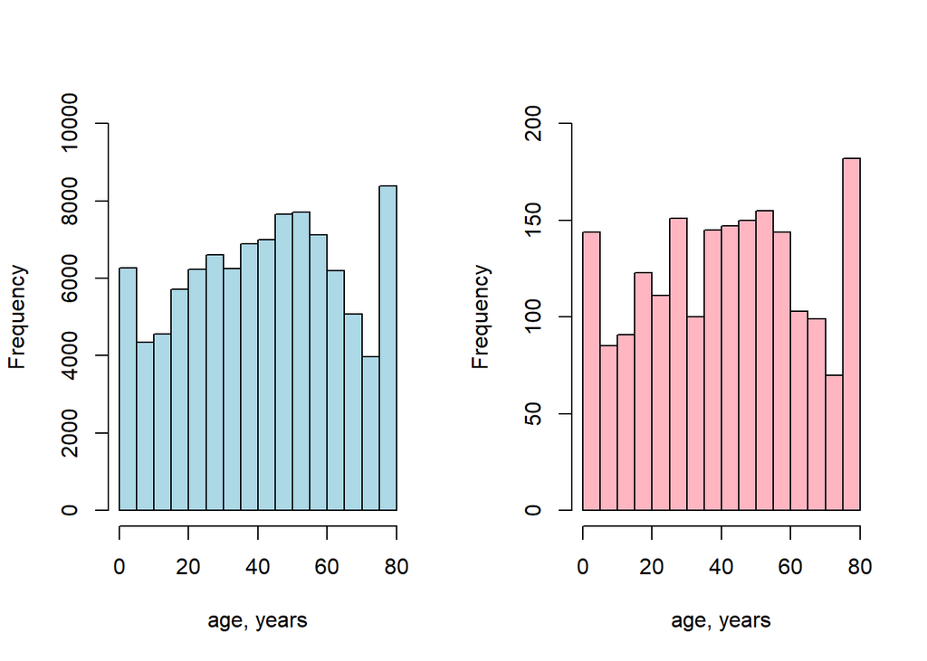

```r
par(mfrow = c(1, 2))
hist(myData$age, breaks = 25,
     ylim = c(0, 10000), col = "lightblue", main = "", xlab = "age, years")
hist(myData.1_2000$age, breaks = 25, ylim = c(0, 200),
     col = "lightpink", main = "", xlab = "age, years")
```

This new dataset appears to be more representative of the original dataset than the dataset of 200 observations. However, we would still like a more adequate representation of the original dataset. Before carrying out another subsetting, the dataset of 2000 observations will be transformed as a matrix.

```r
myMatrix_1_2000 <- as.matrix(myData.1_2000[, -1])
class(myMatrix_1_2000)
```

```
## [1] "matrix" "array"
```

```r
dim(myMatrix_1_2000)
```

```
## [1] 2000    8
```

```r
head(myMatrix_1_2000)
```

```
##   age hypertension heart_disease smoking_history   bmi HbA1c_level
## 1  80            0             1               0 25.19         6.6
## 2  54            0             0              99 27.32         6.6
## 3  28            0             0               0 27.32         5.7
## 4  36            0             0               4 23.45         5.0
## 5  76            1             1               4 20.14         4.8
## 6  20            0             0               0 27.32         6.6
##   blood_glucose_level diabetes
## 1                 140        0
## 2                  80        0
## 3                 158        0
## 4                 155        0
## 5                 155        0
## 6                  85        0
```

```r
tail(myMatrix_1_2000)
```

```
##      age hypertension heart_disease smoking_history   bmi HbA1c_level
## 1995  28            0             0              99 37.75         3.5
## 1996  53            1             0               0 26.39         5.8
## 1997  43            0             0              99 27.32         5.7
## 1998  80            0             0               0 27.32         6.6
## 1999  71            0             0              99 27.32         6.0
## 2000  60            0             0               1 29.62         3.5
##      blood_glucose_level diabetes
## 1995                 100        0
## 1996                 140        0
## 1997                 159        0
## 1998                 100        0
## 1999                 155        0
## 2000                 158        0
```

The new subsetting will be done using the function “sample()”. This function randomly selects a given number of observations. The random selection of the observations, in a combination with a larger size of the new dataset (e.g., 4,000), should yield a more representative dataset. We will verify the representativeness by, again, building two histograms based on the variable “age”.

Please take a note of the function “set.seed()” below. This function ensures reproducibility of random sampling. Without this function, each new use of function “sample()” would result in creation of a slightly different dataset. The number within the parenthesis (here: 42) is not essential and can be replaced with any other random number.

```r
set.seed(42)
myData.RandomSubset <- myData[sample(nrow(myData), size = 4000), ]
dim(myData.RandomSubset)
```

```
## [1] 4000    9
```

```r
head(myData.RandomSubset)
```

```
##       gender age hypertension heart_disease smoking_history   bmi HbA1c_level
## 61413 Female  13            0             0              99 22.77         6.1
## 54425 Female  60            0             0               0 31.60         3.5
## 99556 Female  27            0             0              99 21.33         5.7
## 74362 Female  43            0             0              99 16.82         4.8
## 46208 Female   6            0             0               0 17.19         4.0
## 47128   Male  51            0             0              99 29.87         4.0
##       blood_glucose_level diabetes
## 61413                  90        0
## 54425                 158        0
## 99556                 158        0
## 74362                 126        0
## 46208                 200        0
## 47128                 200        0
```

```r
tail(myData.RandomSubset)
```

```
##       gender   age hypertension heart_disease smoking_history   bmi HbA1c_level
## 39412 Female 28.00            0             0               2 27.78         3.5
## 44415   Male 26.00            0             0               4 27.32         5.8
## 1203  Female 35.00            0             0               0 27.32         5.8
## 571     Male 37.00            0             0              99 27.32         6.6
## 84372 Female 11.00            0             0              99 25.33         6.6
## 67842   Male  1.08            0             0              99 15.72         5.8
##       blood_glucose_level diabetes
## 39412                 159        0
## 44415                 130        0
## 1203                  159        0
## 571                   100        0
## 84372                 159        0
## 67842                 200        0
```

```r
table(myData.RandomSubset$gender)
```

```
##
## Female   Male  Other
##   2394   1604      2
```

```r
table(myData.RandomSubset$hypertension)
```

```
##
##    0    1
## 3683  317
```

```r
table(myData.RandomSubset$heart_disease)
```

```
##
##    0    1
## 3841  159
```

```r
table(myData.RandomSubset$smoking_history)
```

```
##
##    0    1    2    3    4   99
## 1394  353  164  267  374 1448
```

```r
table(myData.RandomSubset$diabetes)
```

```
##
##    0    1
## 3673  327
```

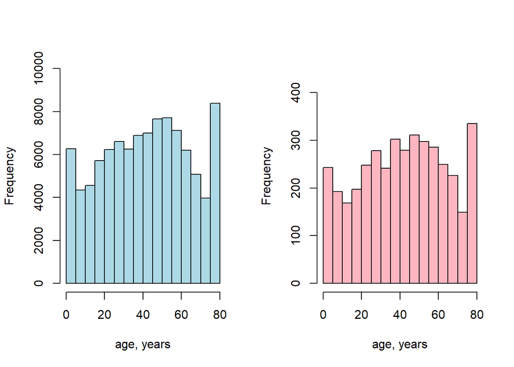

```r
par(mfrow=c(1, 2))
hist(myData$age, breaks = 25,
     ylim = c(0, 10000), col = "lightblue", main = "", xlab = "age, years")
hist(myData.RandomSubset$age, breaks = 25, ylim = c(0, 450),
     col = "lightpink", main = "", xlab = "age, years")
```

The new dataset appears to be very similar to the original dataset and will be used in the majority of the subsequent analyses. But first, we will need to turn this new dataset into a matrix.

```r
myMatrix_RandomSubset <- as.matrix(myData.RandomSubset[, -1])
class(myMatrix_RandomSubset)
```

```
## [1] "matrix" "array"
```

```r
dim(myMatrix_RandomSubset)
```

```
## [1] 4000    8
```

```r
head(myMatrix_RandomSubset)
```

```
##       age hypertension heart_disease smoking_history   bmi HbA1c_level
## 61413  13            0             0              99 22.77         6.1
## 54425  60            0             0               0 31.60         3.5
## 99556  27            0             0              99 21.33         5.7
## 74362  43            0             0              99 16.82         4.8
## 46208   6            0             0               0 17.19         4.0
## 47128  51            0             0              99 29.87         4.0
##       blood_glucose_level diabetes
## 61413                  90        0
## 54425                 158        0
## 99556                 158        0
## 74362                 126        0
## 46208                 200        0
## 47128                 200        0
```

```r
tail(myMatrix_RandomSubset)
```

```
##         age hypertension heart_disease smoking_history   bmi HbA1c_level
## 39412 28.00            0             0               2 27.78         3.5
## 44415 26.00            0             0               4 27.32         5.8
## 1203  35.00            0             0               0 27.32         5.8
## 571   37.00            0             0              99 27.32         6.6
## 84372 11.00            0             0              99 25.33         6.6
## 67842  1.08            0             0              99 15.72         5.8
##       blood_glucose_level diabetes
## 39412                 159        0
## 44415                 130        0
## 1203                  159        0
## 571                   100        0
## 84372                 159        0
## 67842                 200        0
```

The next step should be familiar. We will need to carry out the Z-score normalization using function “scale()”. This will be followed up by calculation of a distance matrix.

```r
myMatrix_RandomSubset_sc <- scale(myMatrix_RandomSubset,
                                  center = TRUE, scale = TRUE)

myDist_RandomSubset <- dist(myMatrix_RandomSubset_sc, method = "euclidean")
```

The next step will be to apply cMDS analysis to the distance matrix and then plot the data points. Please note that due to a substantial size (N = 4,000 observations), cMDS will take some time to be completed.

```r
my_cMDS_RandomSubset <- cmdscale(myDist_RandomSubset, k = 2)
dim(my_cMDS_RandomSubset)
```

```
## [1] 4000    2
```

```r
head(my_cMDS_RandomSubset)
```

```
##              [,1]       [,2]
## 61413  1.66700952 -0.9042866
## 54425 -0.05301932  1.4910104
## 99556  1.05617317 -1.3459152
## 74362  1.52294102 -0.6135034
## 46208  1.24102449 -0.8784099
## 47128  0.32289225 -0.2755591
```

```r
tail(my_cMDS_RandomSubset)
```

```
##              [,1]        [,2]
## 39412  0.75431094  0.70910931
## 44415  0.37280359  0.05930648
## 1203  -0.05254481 -0.07575302
## 571    0.74493887 -0.55313634
## 84372  0.86513199 -1.76115350
## 67842  1.47438975 -2.60031619
```

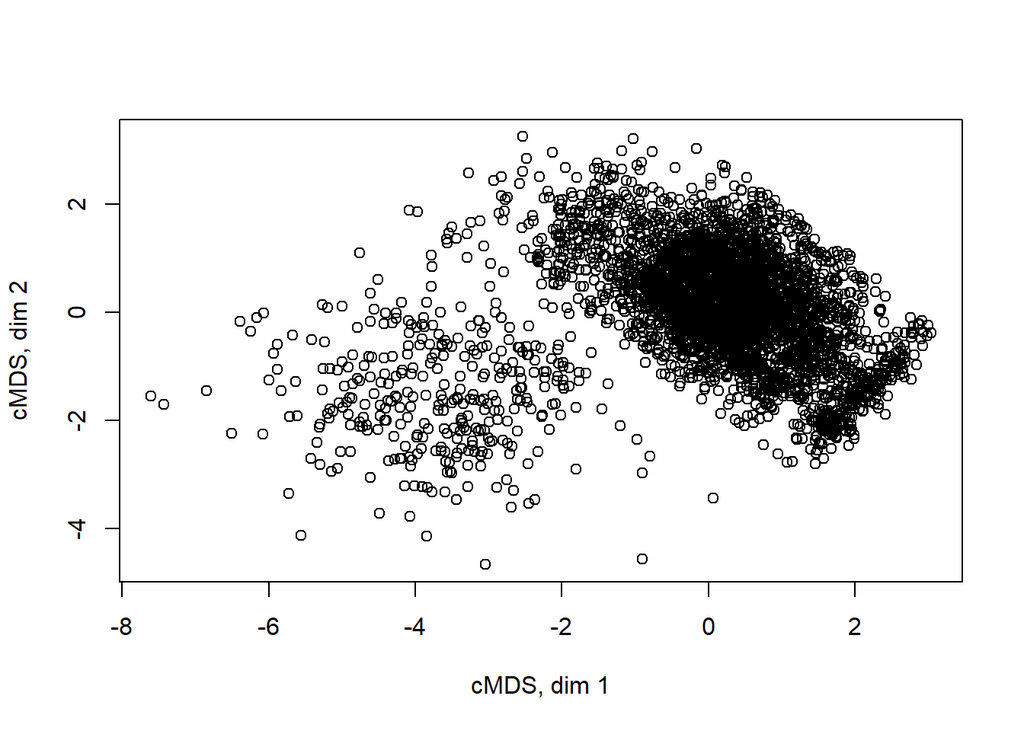

```r
par(mfrow = c(1, 1))
plot(my_cMDS_RandomSubset, xlab = "cMDS, dim 1", ylab = "cMDS, dim 2")
```

Please note that we needed to again use the function “par(mfrow = ())”, this time, to make the plot over one column.

The plot shows two unequally-sized groups (clusters) of data points. The relative proportions of these clusters are different from the gender distribution in this subset (about 60% female patients, 40% male patients, and 0.05% of other genders). So it must be some other variable(s) that contributed to cMDS mapping of two well-formed clusters. We will do some investigation to identify this variable(s).

We will first start with testing the importance of the variable “hypertension” (which is the second variable in the matrix “myMatrix_RandomSubset”). This variable has binary values (that is, “0”s and “1”s). Our assumption is that by replacing the “1”s with zeros in this variable, we will diminish its impact on the ordination of data points by cMDS. In particular, we expect a complete disappearance of the aforementioned well-formed clusters or some degree of fusion of these clusters.

To replace the “1”s, we will use the R function under homonymous name (i.e., “replace()”).

To avoid transformation of the aforementioned matrix, it will be copied into another R object

```r
myMatrix_RandomSubset.var.2 <- myMatrix_RandomSubset
head(myMatrix_RandomSubset.var.2)
```

```
##       age hypertension heart_disease smoking_history   bmi HbA1c_level
## 61413  13            0             0              99 22.77         6.1
## 54425  60            0             0               0 31.60         3.5
## 99556  27            0             0              99 21.33         5.7
## 74362  43            0             0              99 16.82         4.8
## 46208   6            0             0               0 17.19         4.0
## 47128  51            0             0              99 29.87         4.0
##       blood_glucose_level diabetes
## 61413                  90        0
## 54425                 158        0
## 99556                 158        0
## 74362                 126        0
## 46208                 200        0
## 47128                 200        0
```

```r
table(myMatrix_RandomSubset.var.2[, 2])
```

```
##
##    0    1
## 3683  317
```

```r
myMatrix_RandomSubset.var.2[, 2] <- replace(myMatrix_RandomSubset.var.2[, 2],
                                      myMatrix_RandomSubset.var.2[, 2] > 0,
                                      0)
table(myMatrix_RandomSubset.var.2[, 2])
```

```
##
##    0
## 4000
```

```r
myMatrix_RandomSubset.var.2_sc <- scale(myMatrix_RandomSubset.var.2,
                                  center = TRUE, scale = TRUE)

myDist_RandomSubset.var.2 <- dist(myMatrix_RandomSubset.var.2_sc, method = "euclidean")

my_cMDS_RandomSubset.var.2 <- cmdscale(myDist_RandomSubset.var.2, k = 2)
dim(my_cMDS_RandomSubset.var.2)
```

```
## [1] 4000    2
```

```r
head(my_cMDS_RandomSubset.var.2)
```

```
##             [,1]       [,2]
## 61413  1.7617366 -1.1049156
## 54425 -0.1326647  1.7026892
## 99556  1.0506042 -1.5120053
## 74362  1.6174591 -0.7936139
## 46208  1.2517453 -0.9758997
## 47128  0.2484549 -0.2703936
```

```r
tail(my_cMDS_RandomSubset.var.2)
```

```
##             [,1]        [,2]
## 39412  0.7536253  0.78382125
## 44415  0.3007142  0.11720018
## 1203  -0.1886536  0.01949815
## 571    0.7268755 -0.63163400
## 84372  0.8114671 -1.92473753
## 67842  1.4771997 -2.89594804
```

We will then plot the cMDS mapping of the new matrix.

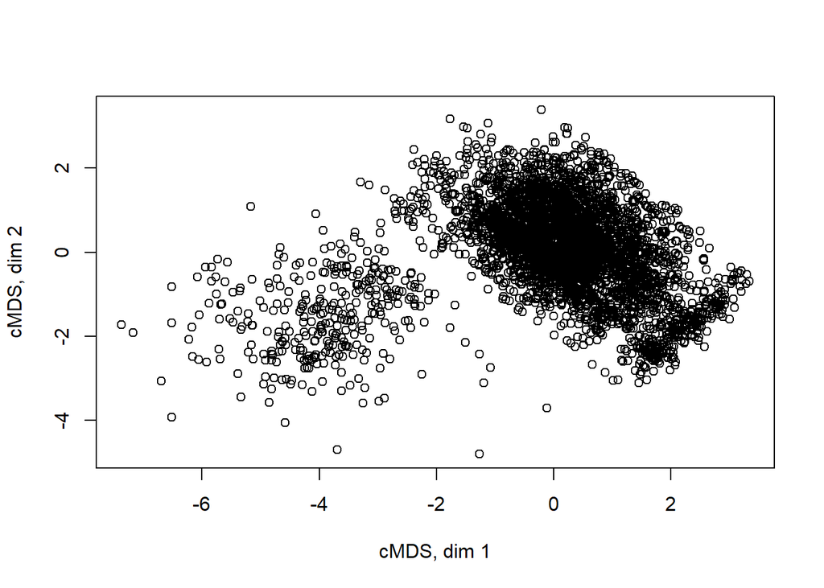

```r
par(mfrow = c(1, 1))
plot(my_cMDS_RandomSubset.var.2, xlab = "cMDS, dim 1", ylab = "cMDS, dim 2")
```

The new plot has barely changed from the original cMDS mapping. This speaks against substantial importance of the “hypertension” variable. We will next try to apply the same approach to the binary variable “diabetes”.

```r
myMatrix_RandomSubset.var.8 <- myMatrix_RandomSubset
head(myMatrix_RandomSubset.var.8)
```

```
##       age hypertension heart_disease smoking_history   bmi HbA1c_level
## 61413  13            0             0              99 22.77         6.1
## 54425  60            0             0               0 31.60         3.5
## 99556  27            0             0              99 21.33         5.7
## 74362  43            0             0              99 16.82         4.8
## 46208   6            0             0               0 17.19         4.0
## 47128  51            0             0              99 29.87         4.0
##       blood_glucose_level diabetes
## 61413                  90        0
## 54425                 158        0
## 99556                 158        0
## 74362                 126        0
## 46208                 200        0
## 47128                 200        0
```

```r
table(myMatrix_RandomSubset.var.8[, 8])
```

```
##
##    0    1
## 3673  327
```

```r
myMatrix_RandomSubset.var.8[, 8] <- replace(myMatrix_RandomSubset.var.8[, 8],
                                        myMatrix_RandomSubset.var.8[, 8] > 0,
                                        0)
table(myMatrix_RandomSubset.var.8[, 8])
```

```
##
##    0
## 4000
```

```r
myMatrix_RandomSubset.var.8_sc <- scale(myMatrix_RandomSubset.var.8,
                                    center = TRUE, scale = TRUE)

myDist_RandomSubset.var.8 <- dist(myMatrix_RandomSubset.var.8_sc, method = "euclidean")

my_cMDS_RandomSubset.var.8 <- cmdscale(myDist_RandomSubset.var.8, k = 2)
dim(my_cMDS_RandomSubset.var.8)
```

```
## [1] 4000    2
```

```r
head(my_cMDS_RandomSubset.var.8)
```

```
##             [,1]       [,2]
## 61413  1.9522555 -0.5586533
## 54425 -0.4869193  1.6046570
## 99556  1.3380837 -1.3138412
## 74362  1.7250117 -0.3717519
## 46208  1.4663380 -0.5620628
## 47128  0.2924382 -0.3307676
```

```r
tail(my_cMDS_RandomSubset.var.8)
```

```
##             [,1]       [,2]
## 39412  0.5973531  1.0760867
## 44415  0.2804081  0.1415234
## 1203  -0.1818207 -0.1857421
## 571    0.8221314 -0.5448942
## 84372  1.2037409 -1.8030656
## 67842  2.0677546 -2.5455438
```

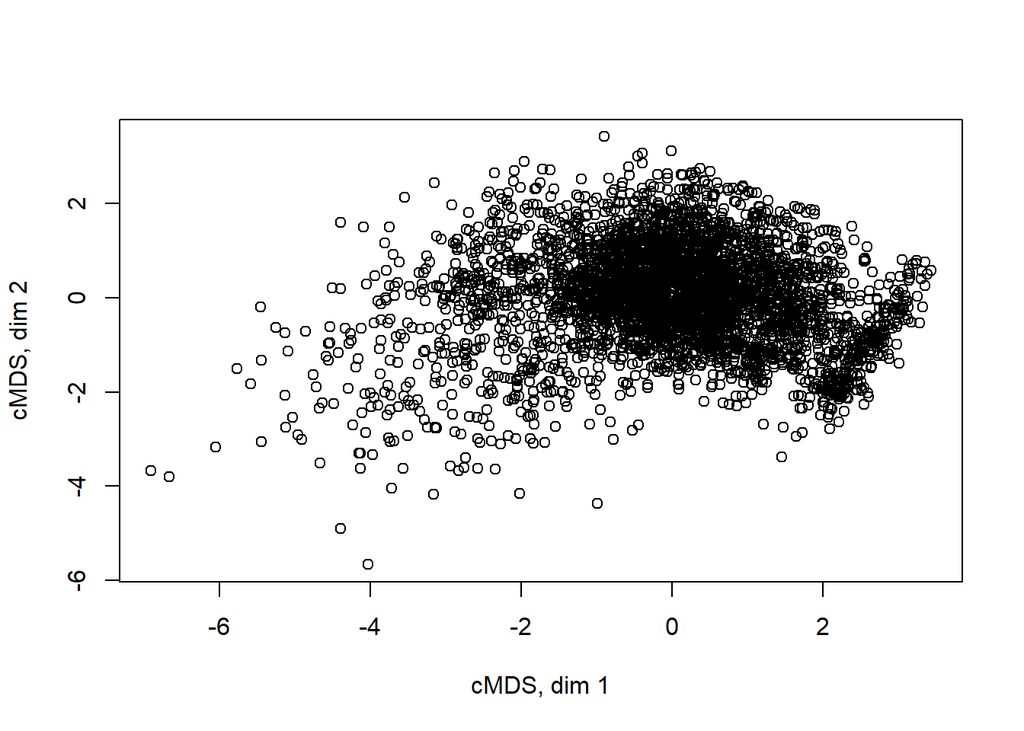

```r
par(mfrow = c(1, 1))
plot(my_cMDS_RandomSubset.var.8, xlab = "cMDS, dim 1", ylab = "cMDS, dim 2")
```

This time, following modification of the “diabetes” variable, the data points of cMDS plot showed a substantially different mapping, supporting the importance of this variable for cMDS mapping.

You should note this approach. It is a variation of a popular method called “sensitivity analysis”. The latter is often used both in statistics and machine learning for evaluation of the relative importance of dataset variables for the overall outcome. You should try to apply this approach to the variable “heart_disease”.

Our investigation will go further. Dataset visualization is an important method in unsupervised learning. Additional information can be presented by using the color, in particular, for a better separation of data points. This will be done next. Since variable “diabetes” turned to be important, the color coding will be applied for this variable.

First, the unmodified “diabetes” variable will be copied into a new R object.

```r
table(myMatrix_RandomSubset[, 8])
```

```
##
##    0    1
## 3673  327
```

```r
diabetes_new_variable <- myMatrix_RandomSubset[, 8]
length(diabetes_new_variable)
```

```
## [1] 4000
```

```r
head(diabetes_new_variable)
```

```
## 61413 54425 99556 74362 46208 47128
##     0     0     0     0     0     0
```

```r
tail(diabetes_new_variable)
```

```
## 39412 44415  1203   571 84372 67842
##     0     0     0     0     0     0
```

Please note that testing of the “head” and “tail” of this new variable did not reveal “1”s, so only “0”s were seen. We will need to control the subsequent data transformation within this variable. We will try to yield a better visualization the binary data within the new variable by showing other parts of the latter.

You also should note that the new variable shows the original row numbers. We will apply R function “class()” to the new variable to find out its class.

```r
class(diabetes_new_variable)
```

```
## [1] "numeric"
```

Please try to explain how a numeric vector can carry row names. In the mean time, we will check the binary data somewhere deeper in the variable

```r
print(diabetes_new_variable[c(2000:2100)])
```

```
## 70684 61510 95348 70693 71851 62505 13457 89665 26637 74175 97527 62728 63400
##     0     0     0     0     0     0     1     0     0     0     0     0     0
## 10507 48028 76651 51363 71913 41343 56046 23458 83329 74411 59218 25350 61349
##     0     0     0     0     0     0     0     0     0     0     0     0     0
## 23772 37450 25065 46975 48644 98762 58921 76431  2606 52235 82354 57436 89649
##     0     0     0     0     0     0     0     0     0     0     0     1     0
## 49212 72040 68303 33174 83454 45435  7271 55922 65361 88950   184 82246 59367
##     0     0     0     0     0     0     0     0     1     0     0     0     0
## 71340 24315 53527 13786   751 25695 63253 47905 30347 40396 19928 49026 54055
##     0     0     1     0     0     0     0     0     0     0     0     0     0
## 95133  8028  9595 21430 20487 57518 32658 14323 79057 35557 63764 92903 22725
##     0     0     0     0     0     0     0     0     0     1     1     0     0
## 11759 66841 68561 61298 29489 35130 96604 46280 94347 55344 75013 88849  5249
##     0     0     0     0     0     0     0     1     0     0     0     0     0
## 52635  2138 50643 95279 41669 79002 53634 88524 86311 33399
##     0     0     0     0     0     1     0     0     0     0
```

This approach worked better, and we can see both “0”s and “1”s. We will next replace the “0”s with the label “no_diabetes”, and the “1”s with the label “diabetes”. This will simplify the subsequent creation of the legend and the color codes.

```r
diabetes_new_variable <- replace(diabetes_new_variable,
                                 diabetes_new_variable == 0,
                                 "no_diabetes")
print(diabetes_new_variable[c(2000:2100)])
```

```
##         70684         61510         95348         70693         71851
## "no_diabetes" "no_diabetes" "no_diabetes" "no_diabetes" "no_diabetes"
##         62505         13457         89665         26637         74175
## "no_diabetes"           "1" "no_diabetes" "no_diabetes" "no_diabetes"
##         97527         62728         63400         10507         48028
## "no_diabetes" "no_diabetes" "no_diabetes" "no_diabetes" "no_diabetes"
##         76651         51363         71913         41343         56046
## "no_diabetes" "no_diabetes" "no_diabetes" "no_diabetes" "no_diabetes"
##         23458         83329         74411         59218         25350
## "no_diabetes" "no_diabetes" "no_diabetes" "no_diabetes" "no_diabetes"
##         61349         23772         37450         25065         46975
## "no_diabetes" "no_diabetes" "no_diabetes" "no_diabetes" "no_diabetes"
##         48644         98762         58921         76431          2606
## "no_diabetes" "no_diabetes" "no_diabetes" "no_diabetes" "no_diabetes"
##         52235         82354         57436         89649         49212
## "no_diabetes" "no_diabetes"           "1" "no_diabetes" "no_diabetes"
##         72040         68303         33174         83454         45435
## "no_diabetes" "no_diabetes" "no_diabetes" "no_diabetes" "no_diabetes"
##          7271         55922         65361         88950           184
## "no_diabetes" "no_diabetes"           "1" "no_diabetes" "no_diabetes"
##         82246         59367         71340         24315         53527
## "no_diabetes" "no_diabetes" "no_diabetes" "no_diabetes"           "1"
##         13786           751         25695         63253         47905
## "no_diabetes" "no_diabetes" "no_diabetes" "no_diabetes" "no_diabetes"
##         30347         40396         19928         49026         54055
## "no_diabetes" "no_diabetes" "no_diabetes" "no_diabetes" "no_diabetes"
##         95133          8028          9595         21430         20487
## "no_diabetes" "no_diabetes" "no_diabetes" "no_diabetes" "no_diabetes"
##         57518         32658         14323         79057         35557
## "no_diabetes" "no_diabetes" "no_diabetes" "no_diabetes"           "1"
##         63764         92903         22725         11759         66841
##           "1" "no_diabetes" "no_diabetes" "no_diabetes" "no_diabetes"
##         68561         61298         29489         35130         96604
## "no_diabetes" "no_diabetes" "no_diabetes" "no_diabetes" "no_diabetes"
##         46280         94347         55344         75013         88849
##           "1" "no_diabetes" "no_diabetes" "no_diabetes" "no_diabetes"
##          5249         52635          2138         50643         95279
## "no_diabetes" "no_diabetes" "no_diabetes" "no_diabetes" "no_diabetes"
##         41669         79002         53634         88524         86311
## "no_diabetes"           "1" "no_diabetes" "no_diabetes" "no_diabetes"
##         33399
## "no_diabetes"
```

```r
diabetes_new_variable <- replace(diabetes_new_variable,
                                 diabetes_new_variable == 1,
                                 "diabetes")
print(diabetes_new_variable[c(2000:2100)])
```

```
##         70684         61510         95348         70693         71851
## "no_diabetes" "no_diabetes" "no_diabetes" "no_diabetes" "no_diabetes"
##         62505         13457         89665         26637         74175
## "no_diabetes"    "diabetes" "no_diabetes" "no_diabetes" "no_diabetes"
##         97527         62728         63400         10507         48028
## "no_diabetes" "no_diabetes" "no_diabetes" "no_diabetes" "no_diabetes"
##         76651         51363         71913         41343         56046
## "no_diabetes" "no_diabetes" "no_diabetes" "no_diabetes" "no_diabetes"
##         23458         83329         74411         59218         25350
## "no_diabetes" "no_diabetes" "no_diabetes" "no_diabetes" "no_diabetes"
##         61349         23772         37450         25065         46975
## "no_diabetes" "no_diabetes" "no_diabetes" "no_diabetes" "no_diabetes"
##         48644         98762         58921         76431          2606
## "no_diabetes" "no_diabetes" "no_diabetes" "no_diabetes" "no_diabetes"
##         52235         82354         57436         89649         49212
## "no_diabetes" "no_diabetes"    "diabetes" "no_diabetes" "no_diabetes"
##         72040         68303         33174         83454         45435
## "no_diabetes" "no_diabetes" "no_diabetes" "no_diabetes" "no_diabetes"
##          7271         55922         65361         88950           184
## "no_diabetes" "no_diabetes"    "diabetes" "no_diabetes" "no_diabetes"
##         82246         59367         71340         24315         53527
## "no_diabetes" "no_diabetes" "no_diabetes" "no_diabetes"    "diabetes"
##         13786           751         25695         63253         47905
## "no_diabetes" "no_diabetes" "no_diabetes" "no_diabetes" "no_diabetes"
##         30347         40396         19928         49026         54055
## "no_diabetes" "no_diabetes" "no_diabetes" "no_diabetes" "no_diabetes"
##         95133          8028          9595         21430         20487
## "no_diabetes" "no_diabetes" "no_diabetes" "no_diabetes" "no_diabetes"
##         57518         32658         14323         79057         35557
## "no_diabetes" "no_diabetes" "no_diabetes" "no_diabetes"    "diabetes"
##         63764         92903         22725         11759         66841
##    "diabetes" "no_diabetes" "no_diabetes" "no_diabetes" "no_diabetes"
##         68561         61298         29489         35130         96604
## "no_diabetes" "no_diabetes" "no_diabetes" "no_diabetes" "no_diabetes"
##         46280         94347         55344         75013         88849
##    "diabetes" "no_diabetes" "no_diabetes" "no_diabetes" "no_diabetes"
##          5249         52635          2138         50643         95279
## "no_diabetes" "no_diabetes" "no_diabetes" "no_diabetes" "no_diabetes"
##         41669         79002         53634         88524         86311
## "no_diabetes"    "diabetes" "no_diabetes" "no_diabetes" "no_diabetes"
##         33399
## "no_diabetes"
```

The label replacement worked well. The next step will be to assign a proper type to the variable. Typically, replacement from the integer or numeric values to character labels ends up with the variable silently changing its data type You should be aware that such silent data type changes should be controlled, or else the subsequent programming may lead to an error.

```r
class(diabetes_new_variable)
```

```
## [1] "character"
```

```r
diabetes_new_variable <- as.factor(diabetes_new_variable)
class(diabetes_new_variable)
```

```
## [1] "factor"
```

```r
levels(diabetes_new_variable)
```

```
## [1] "diabetes"    "no_diabetes"
```

We will next produce a data frame with coordinates of cMDS mapping.

```r
my_cMDS_RandomSubset_df <- as.data.frame(my_cMDS_RandomSubset)
class(my_cMDS_RandomSubset_df)
```

```
## [1] "data.frame"
```

```r
dim(my_cMDS_RandomSubset_df)
```

```
## [1] 4000    2
```

```r
head(my_cMDS_RandomSubset_df)
```

```
##                V1         V2
## 61413  1.66700952 -0.9042866
## 54425 -0.05301932  1.4910104
## 99556  1.05617317 -1.3459152
## 74362  1.52294102 -0.6135034
## 46208  1.24102449 -0.8784099
## 47128  0.32289225 -0.2755591
```

```r
tail(my_cMDS_RandomSubset_df)
```

```
##                V1          V2
## 39412  0.75431094  0.70910931
## 44415  0.37280359  0.05930648
## 1203  -0.05254481 -0.07575302
## 571    0.74493887 -0.55313634
## 84372  0.86513199 -1.76115350
## 67842  1.47438975 -2.60031619
```

The next step is to combine the new variable with the “diabetes” / “no_diabetes” labels. Note that the variable will be added twice (so this is not a mistake).

```r
my_cMDS_RandomSubset_df <- cbind.data.frame(my_cMDS_RandomSubset_df,
                                            diabetes_new_variable,
                                            diabetes_new_variable)
head(my_cMDS_RandomSubset_df)
```

```
##                V1         V2 diabetes_new_variable diabetes_new_variable
## 61413  1.66700952 -0.9042866           no_diabetes           no_diabetes
## 54425 -0.05301932  1.4910104           no_diabetes           no_diabetes
## 99556  1.05617317 -1.3459152           no_diabetes           no_diabetes
## 74362  1.52294102 -0.6135034           no_diabetes           no_diabetes
## 46208  1.24102449 -0.8784099           no_diabetes           no_diabetes
## 47128  0.32289225 -0.2755591           no_diabetes           no_diabetes
```

```r
tail(my_cMDS_RandomSubset_df)
```

```
##                V1          V2 diabetes_new_variable diabetes_new_variable
## 39412  0.75431094  0.70910931           no_diabetes           no_diabetes
## 44415  0.37280359  0.05930648           no_diabetes           no_diabetes
## 1203  -0.05254481 -0.07575302           no_diabetes           no_diabetes
## 571    0.74493887 -0.55313634           no_diabetes           no_diabetes
## 84372  0.86513199 -1.76115350           no_diabetes           no_diabetes
## 67842  1.47438975 -2.60031619           no_diabetes           no_diabetes
```

This will replace the variable names in the new data frame.

```r
colnames(my_cMDS_RandomSubset_df) <- c("V1", "V2",
                                       "diabetes_status",
                                       "color")
head(my_cMDS_RandomSubset_df)
```

```
##                V1         V2 diabetes_status       color
## 61413  1.66700952 -0.9042866     no_diabetes no_diabetes
## 54425 -0.05301932  1.4910104     no_diabetes no_diabetes
## 99556  1.05617317 -1.3459152     no_diabetes no_diabetes
## 74362  1.52294102 -0.6135034     no_diabetes no_diabetes
## 46208  1.24102449 -0.8784099     no_diabetes no_diabetes
## 47128  0.32289225 -0.2755591     no_diabetes no_diabetes
```

Thereby, we obtained two identical variables carrying different names: “diabetes_status” and “color”. The labels in the latter variable will now be transformed into the labels that code for color definitions. But first, the “color” variable needs to be transformed into the “character” type variable. Otherwise, the replacement won’t be successful due to the limitations of the “factor” type objects.

```r
my_cMDS_RandomSubset_df$color <- as.character(my_cMDS_RandomSubset_df$color)
class(my_cMDS_RandomSubset_df$color)
```

```
## [1] "character"
```

```r
my_cMDS_RandomSubset_df$color <- replace(my_cMDS_RandomSubset_df$color,
                                         my_cMDS_RandomSubset_df$color ==
                                           "no_diabetes",
                                         "cornflowerblue")
print(my_cMDS_RandomSubset_df$color[c(2000:2100)])
```

```
##   [1] "cornflowerblue" "cornflowerblue" "cornflowerblue" "cornflowerblue"
##   [5] "cornflowerblue" "cornflowerblue" "diabetes"       "cornflowerblue"
##   [9] "cornflowerblue" "cornflowerblue" "cornflowerblue" "cornflowerblue"
##  [13] "cornflowerblue" "cornflowerblue" "cornflowerblue" "cornflowerblue"
##  [17] "cornflowerblue" "cornflowerblue" "cornflowerblue" "cornflowerblue"
##  [21] "cornflowerblue" "cornflowerblue" "cornflowerblue" "cornflowerblue"
##  [25] "cornflowerblue" "cornflowerblue" "cornflowerblue" "cornflowerblue"
##  [29] "cornflowerblue" "cornflowerblue" "cornflowerblue" "cornflowerblue"
##  [33] "cornflowerblue" "cornflowerblue" "cornflowerblue" "cornflowerblue"
##  [37] "cornflowerblue" "diabetes"       "cornflowerblue" "cornflowerblue"
##  [41] "cornflowerblue" "cornflowerblue" "cornflowerblue" "cornflowerblue"
##  [45] "cornflowerblue" "cornflowerblue" "cornflowerblue" "diabetes"
##  [49] "cornflowerblue" "cornflowerblue" "cornflowerblue" "cornflowerblue"
##  [53] "cornflowerblue" "cornflowerblue" "diabetes"       "cornflowerblue"
##  [57] "cornflowerblue" "cornflowerblue" "cornflowerblue" "cornflowerblue"
##  [61] "cornflowerblue" "cornflowerblue" "cornflowerblue" "cornflowerblue"
##  [65] "cornflowerblue" "cornflowerblue" "cornflowerblue" "cornflowerblue"
##  [69] "cornflowerblue" "cornflowerblue" "cornflowerblue" "cornflowerblue"
##  [73] "cornflowerblue" "cornflowerblue" "diabetes"       "diabetes"
##  [77] "cornflowerblue" "cornflowerblue" "cornflowerblue" "cornflowerblue"
##  [81] "cornflowerblue" "cornflowerblue" "cornflowerblue" "cornflowerblue"
##  [85] "cornflowerblue" "diabetes"       "cornflowerblue" "cornflowerblue"
##  [89] "cornflowerblue" "cornflowerblue" "cornflowerblue" "cornflowerblue"
##  [93] "cornflowerblue" "cornflowerblue" "cornflowerblue" "cornflowerblue"
##  [97] "diabetes"       "cornflowerblue" "cornflowerblue" "cornflowerblue"
## [101] "cornflowerblue"
```

```r
my_cMDS_RandomSubset_df$color <- replace(my_cMDS_RandomSubset_df$color,
                                         my_cMDS_RandomSubset_df$color ==
                                           "diabetes",
                                         "palevioletred1")
print(my_cMDS_RandomSubset_df$color[c(2000:2100)])
```

```
##   [1] "cornflowerblue" "cornflowerblue" "cornflowerblue" "cornflowerblue"
##   [5] "cornflowerblue" "cornflowerblue" "palevioletred1" "cornflowerblue"
##   [9] "cornflowerblue" "cornflowerblue" "cornflowerblue" "cornflowerblue"
##  [13] "cornflowerblue" "cornflowerblue" "cornflowerblue" "cornflowerblue"
##  [17] "cornflowerblue" "cornflowerblue" "cornflowerblue" "cornflowerblue"
##  [21] "cornflowerblue" "cornflowerblue" "cornflowerblue" "cornflowerblue"
##  [25] "cornflowerblue" "cornflowerblue" "cornflowerblue" "cornflowerblue"
##  [29] "cornflowerblue" "cornflowerblue" "cornflowerblue" "cornflowerblue"
##  [33] "cornflowerblue" "cornflowerblue" "cornflowerblue" "cornflowerblue"
##  [37] "cornflowerblue" "palevioletred1" "cornflowerblue" "cornflowerblue"
##  [41] "cornflowerblue" "cornflowerblue" "cornflowerblue" "cornflowerblue"
##  [45] "cornflowerblue" "cornflowerblue" "cornflowerblue" "palevioletred1"
##  [49] "cornflowerblue" "cornflowerblue" "cornflowerblue" "cornflowerblue"
##  [53] "cornflowerblue" "cornflowerblue" "palevioletred1" "cornflowerblue"
##  [57] "cornflowerblue" "cornflowerblue" "cornflowerblue" "cornflowerblue"
##  [61] "cornflowerblue" "cornflowerblue" "cornflowerblue" "cornflowerblue"
##  [65] "cornflowerblue" "cornflowerblue" "cornflowerblue" "cornflowerblue"
##  [69] "cornflowerblue" "cornflowerblue" "cornflowerblue" "cornflowerblue"
##  [73] "cornflowerblue" "cornflowerblue" "palevioletred1" "palevioletred1"
##  [77] "cornflowerblue" "cornflowerblue" "cornflowerblue" "cornflowerblue"
##  [81] "cornflowerblue" "cornflowerblue" "cornflowerblue" "cornflowerblue"
##  [85] "cornflowerblue" "palevioletred1" "cornflowerblue" "cornflowerblue"
##  [89] "cornflowerblue" "cornflowerblue" "cornflowerblue" "cornflowerblue"
##  [93] "cornflowerblue" "cornflowerblue" "cornflowerblue" "cornflowerblue"
##  [97] "palevioletred1" "cornflowerblue" "cornflowerblue" "cornflowerblue"
## [101] "cornflowerblue"
```

Thereby we obtained a data frame that has two variables with coordinates for cMDS mapping (respectively, first and second dimensions), one variable with the labels for the diabetes status (“diabetes” / “no_diabetes”), and one variable that bears color codes (“cornflowerblue” for observations with the label “no diabetes” and “palevioletred1” for the label “diabetes”). We will next test the color distribution in the aforementioned clusters. We will also add a legend to the plot to facilitate the appreciation of data points.

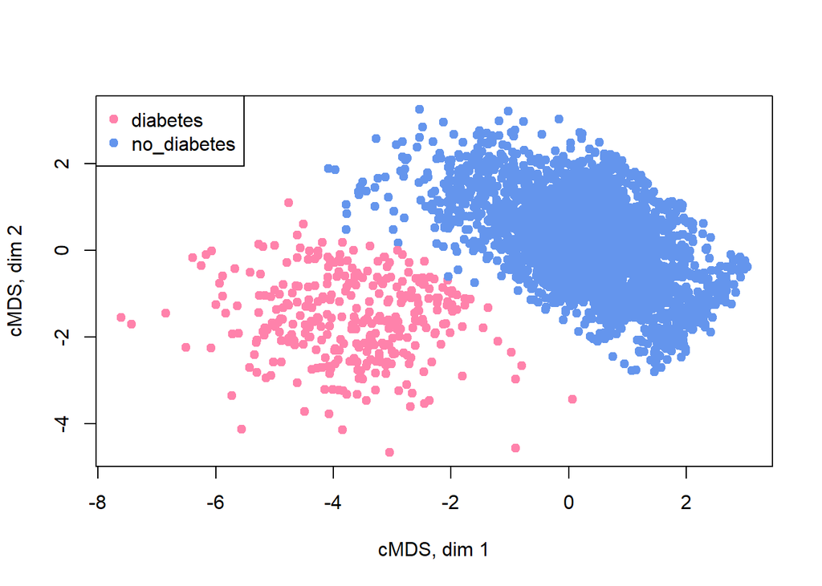

```r
plot(x = my_cMDS_RandomSubset_df$V1,
     y = my_cMDS_RandomSubset_df$V2, pch = 19,
     xlab = "cMDS, dim 1", ylab = "cMDS, dim 2",
     col = my_cMDS_RandomSubset_df$color)
legend(x = "topleft", pch = 19, legend = c("diabetes", "no_diabetes"),
       col = c("palevioletred1", "cornflowerblue"))
```

As this color visualization demonstrates, the great majority of data points fall within the expected clusters. There are a few “no_diabetes” data points that appear on the border between the two clusters, but largely, the separation between the “no_diabetes” and “diabetes” data points is quite sharp.

Please try to carry out a similar color separation using the previously tested variable “hypertension”.

It was mentioned before that there are some “no_diabetes” data points that are “mingled” with the “diabetes” data points. We will next test whether the cluster separation will be improved if we use fewer data points (e.g., 200 observations).

```r
myMatrix_10001_10200_sc <- scale(myMatrix_10001_10200,
                            center = TRUE, scale = TRUE)
myDist_10000_10200 <- dist(myMatrix_10001_10200_sc, method = "euclidean")

my_cMDS_10000_10200 <- cmdscale(myDist_10000_10200, k = 2)
dim(my_cMDS_10000_10200)
```

```
## [1] 200   2
```

```r
head(my_cMDS_10000_10200)
```

```
##             [,1]       [,2]
## 10001  0.7104530 -0.6442034
## 10002 -1.0775877 -0.4917513
## 10003  0.8131145  1.1202565
## 10004  1.0845353  0.3684047
## 10005 -1.7040463 -1.4834040
## 10006 -0.5336243  0.4443846
```

```r
tail(my_cMDS_10000_10200)
```

```
##              [,1]       [,2]
## 10195  1.88212115  2.4946453
## 10196  0.07662631  0.2352971
## 10197 -0.14629772  0.7935048
## 10198  0.28626035  0.8548784
## 10199 -0.15799688 -0.1780309
## 10200  1.47928149  0.9174652
```

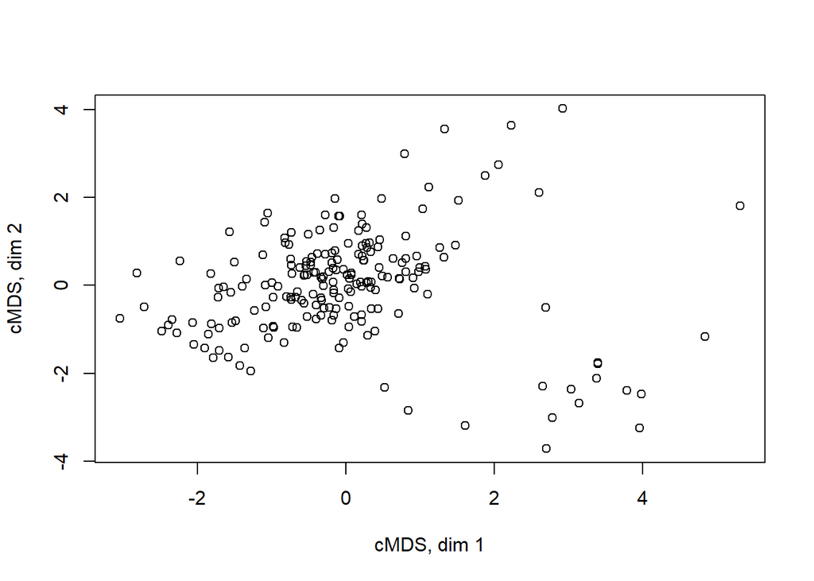

```r
par(mfrow = c(1, 1))
plot(my_cMDS_10000_10200, xlab = "cMDS, dim 1", ylab = "cMDS, dim 2")
```

```r
diabetes_new_variable_200 <- myMatrix_10001_10200[, 8]
length(diabetes_new_variable_200)
```

```
## [1] 200
```

```r
head(diabetes_new_variable_200)
```

```
## 10001 10002 10003 10004 10005 10006
##     0     0     0     0     0     0
```

```r
tail(diabetes_new_variable_200)
```

```
## 10195 10196 10197 10198 10199 10200
##     0     0     0     0     0     0
```

```r
print(diabetes_new_variable_200[c(120:140)])
```

```
## 10120 10121 10122 10123 10124 10125 10126 10127 10128 10129 10130 10131 10132
##     0     0     0     0     0     0     0     0     0     0     0     0     0
## 10133 10134 10135 10136 10137 10138 10139 10140
##     0     0     0     0     0     1     0     0
```

```r
diabetes_new_variable_200 <- replace(diabetes_new_variable_200,
                                     diabetes_new_variable_200 == 0,
                                     "no_diabetes")
print(diabetes_new_variable_200[c(120:140)])
```

```
##         10120         10121         10122         10123         10124
## "no_diabetes" "no_diabetes" "no_diabetes" "no_diabetes" "no_diabetes"
##         10125         10126         10127         10128         10129
## "no_diabetes" "no_diabetes" "no_diabetes" "no_diabetes" "no_diabetes"
##         10130         10131         10132         10133         10134
## "no_diabetes" "no_diabetes" "no_diabetes" "no_diabetes" "no_diabetes"
##         10135         10136         10137         10138         10139
## "no_diabetes" "no_diabetes" "no_diabetes"           "1" "no_diabetes"
##         10140
## "no_diabetes"
```

```r
diabetes_new_variable_200 <- replace(diabetes_new_variable_200,
                                     diabetes_new_variable_200 == 1,
                                     "diabetes")
print(diabetes_new_variable_200[c(120:140)])
```

```
##         10120         10121         10122         10123         10124
## "no_diabetes" "no_diabetes" "no_diabetes" "no_diabetes" "no_diabetes"
##         10125         10126         10127         10128         10129
## "no_diabetes" "no_diabetes" "no_diabetes" "no_diabetes" "no_diabetes"
##         10130         10131         10132         10133         10134
## "no_diabetes" "no_diabetes" "no_diabetes" "no_diabetes" "no_diabetes"
##         10135         10136         10137         10138         10139
## "no_diabetes" "no_diabetes" "no_diabetes"    "diabetes" "no_diabetes"
##         10140
## "no_diabetes"
```

```r
class(diabetes_new_variable_200)
```

```
## [1] "character"
```

```r
diabetes_new_variable_200 <- as.factor(diabetes_new_variable_200)
class(diabetes_new_variable_200)
```

```
## [1] "factor"
```

```r
levels(diabetes_new_variable_200)
```

```
## [1] "diabetes"    "no_diabetes"
```

```r
my_cMDS_10000_10200_df <- as.data.frame(my_cMDS_10000_10200)
class(my_cMDS_10000_10200_df)
```

```
## [1] "data.frame"
```

```r
dim(my_cMDS_10000_10200_df)
```

```
## [1] 200   2
```

```r
head(my_cMDS_10000_10200_df)
```

```
##               V1         V2
## 10001  0.7104530 -0.6442034
## 10002 -1.0775877 -0.4917513
## 10003  0.8131145  1.1202565
## 10004  1.0845353  0.3684047
## 10005 -1.7040463 -1.4834040
## 10006 -0.5336243  0.4443846
```

```r
tail(my_cMDS_10000_10200_df)
```

```
##                V1         V2
## 10195  1.88212115  2.4946453
## 10196  0.07662631  0.2352971
## 10197 -0.14629772  0.7935048
## 10198  0.28626035  0.8548784
## 10199 -0.15799688 -0.1780309
## 10200  1.47928149  0.9174652
```

```r
my_cMDS_10000_10200_df <- cbind.data.frame(my_cMDS_10000_10200_df,
                                           diabetes_new_variable_200,
                                           diabetes_new_variable_200)
head(my_cMDS_10000_10200_df)
```

```
##               V1         V2 diabetes_new_variable_200 diabetes_new_variable_200
## 10001  0.7104530 -0.6442034               no_diabetes               no_diabetes
## 10002 -1.0775877 -0.4917513               no_diabetes               no_diabetes
## 10003  0.8131145  1.1202565               no_diabetes               no_diabetes
## 10004  1.0845353  0.3684047               no_diabetes               no_diabetes
## 10005 -1.7040463 -1.4834040               no_diabetes               no_diabetes
## 10006 -0.5336243  0.4443846               no_diabetes               no_diabetes
```

```r
tail(my_cMDS_10000_10200_df)
```

```
##                V1         V2 diabetes_new_variable_200
## 10195  1.88212115  2.4946453               no_diabetes
## 10196  0.07662631  0.2352971               no_diabetes
## 10197 -0.14629772  0.7935048               no_diabetes
## 10198  0.28626035  0.8548784               no_diabetes
## 10199 -0.15799688 -0.1780309               no_diabetes
## 10200  1.47928149  0.9174652               no_diabetes
##       diabetes_new_variable_200
## 10195               no_diabetes
## 10196               no_diabetes
## 10197               no_diabetes
## 10198               no_diabetes
## 10199               no_diabetes
## 10200               no_diabetes
```

```r
colnames(my_cMDS_10000_10200_df) <- c("V1", "V2",
                                       "diabetes_status",
                                       "color")
head(my_cMDS_10000_10200_df)
```

```
##               V1         V2 diabetes_status       color
## 10001  0.7104530 -0.6442034     no_diabetes no_diabetes
## 10002 -1.0775877 -0.4917513     no_diabetes no_diabetes
## 10003  0.8131145  1.1202565     no_diabetes no_diabetes
## 10004  1.0845353  0.3684047     no_diabetes no_diabetes
## 10005 -1.7040463 -1.4834040     no_diabetes no_diabetes
## 10006 -0.5336243  0.4443846     no_diabetes no_diabetes
```

```r
my_cMDS_10000_10200_df$color <- as.character(my_cMDS_10000_10200_df$color)
class(my_cMDS_10000_10200_df$color)
```

```
## [1] "character"
```

```r
my_cMDS_10000_10200_df$color <- replace(my_cMDS_10000_10200_df$color,
                                        my_cMDS_10000_10200_df$color ==
                                           "no_diabetes",
                                         "cornflowerblue")
print(my_cMDS_10000_10200_df$color[c(120:140)])
```

```
##  [1] "cornflowerblue" "cornflowerblue" "cornflowerblue" "cornflowerblue"
##  [5] "cornflowerblue" "cornflowerblue" "cornflowerblue" "cornflowerblue"
##  [9] "cornflowerblue" "cornflowerblue" "cornflowerblue" "cornflowerblue"
## [13] "cornflowerblue" "cornflowerblue" "cornflowerblue" "cornflowerblue"
## [17] "cornflowerblue" "cornflowerblue" "diabetes"       "cornflowerblue"
## [21] "cornflowerblue"
```

```r
my_cMDS_10000_10200_df$color <- replace(my_cMDS_10000_10200_df$color,
                                        my_cMDS_10000_10200_df$color ==
                                           "diabetes",
                                         "palevioletred1")
print(my_cMDS_10000_10200_df$color[c(120:140)])
```

```
##  [1] "cornflowerblue" "cornflowerblue" "cornflowerblue" "cornflowerblue"
##  [5] "cornflowerblue" "cornflowerblue" "cornflowerblue" "cornflowerblue"
##  [9] "cornflowerblue" "cornflowerblue" "cornflowerblue" "cornflowerblue"
## [13] "cornflowerblue" "cornflowerblue" "cornflowerblue" "cornflowerblue"
## [17] "cornflowerblue" "cornflowerblue" "palevioletred1" "cornflowerblue"
## [21] "cornflowerblue"
```

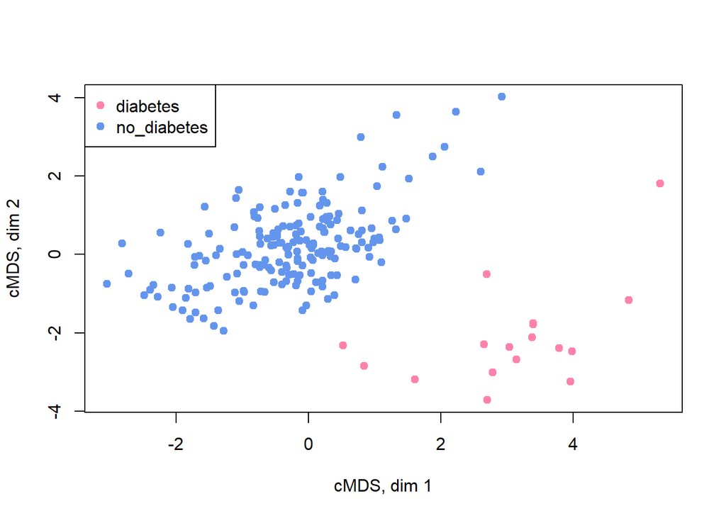

```r
plot(x = my_cMDS_10000_10200_df$V1,
     y = my_cMDS_10000_10200_df$V2,
     pch = 19,
     xlab = "cMDS, dim 1", ylab = "cMDS, dim 2",
     col = my_cMDS_10000_10200_df$color)
legend(x = "topleft", pch = 19, legend = c("diabetes", "no_diabetes"),
       col = c("palevioletred1", "cornflowerblue"))
```

As expected, the separation of data points is much sharper when fewer data points are mapped by cMDS.

This little study demonstrates the strenghs and limitations of cMDS. 1. This method is metric and linear. This makes the mapping predictable: if there is a good separation with many data points, there is a good chance that the separation will improve when there is fewer data points. 2. The “sensitivity analysis” method is very easy to carry out with cMDS mapping due to the aforementioned predictivity. Also, the above exploration was not designed to demonstrate this, but cMDS is a very robust method (meaning that it is not too sensitive to small changes but will respond to a variable transformation with substantial impact). 3. The biggest limitation of cMDS is that it struggles with large datasets, both with computational time and the actual mapping. In particular, even the well-formed clusters will eventually be lost if the dataset has too many data points.

The subsequently addressed non-linear ordination technique t-SNE is one of the many attempts to overcome the limitations of cMDS.

Important note! Neither cMDS nor t-SNE are clustering methods per se. Their primary aim is ordination. Ordination in this context means the data point mapping in a low-dimensional space. The “by-products” of this ordination could visualization of potential clusters or demonstration of other hidden patterns within the dataset. Yet these are not the main purpose why cMDS or t-SNE are applied to complex biomedical datasets. There are dedicated clustering methods (e.g., partition around medoids, k-means clustering, hierarchical clustering) whose primarily aim to identify the clusters within the analyzed dataset. The clustering methods will be addressed separately.

As next, we will apply t-SNE to the “random” subset of the “diabetes_prediction_dataset”.

Please take a note of the following things: 1. The use of the “set.seed()” function. Like many other machine learning methods, t-SNE has a certain built-in stochasticity. To make the analysis reproducible, we will need to define the “seed”. 2. The computational time for t-SNE mapping (which is much shorter than with cMDS). 3. The “perplexity” hyperparameter. It will be addressed below. 4. The number of iterations. This, too, will be addressed below.

The input for t-SNE can be original data (with or without PCA pre-processing) or a distance matrix. For better comparison, we will use the previously calculated distance matrix. Function “str()” will show the structure of t-SNE analysis. The argument “dims = 2” means that we want to have the mapping in two dimensions. The argument “check_duplicates = FALSE” is necessary to avoid error messages that appear when are observations with very similar attributes.

```r
set.seed(42)
myRtsne_result <- Rtsne(myDist_RandomSubset, dims = 2, perplexity = 40,
                        pca = FALSE, max_iter = 333, is_distance = TRUE,
                        check_duplicates = FALSE)
str(myRtsne_result)
```

```
## List of 13
##  $ N                  : int 4000
##  $ Y                  : num [1:4000, 1:2] 6.9037 -4.7526 0.0451 10.7571 -3.0704 ...
##  $ costs              : num [1:4000] 0.000349 0.000398 0.000579 0.000387 0.000394 ...
##  $ itercosts          : num [1:7] 81.8 67.9 65.4 64.5 64 ...
##  $ perplexity         : num 40
##  $ theta              : num 0.5
##  $ max_iter           : num 333
##  $ stop_lying_iter    : int 250
##  $ mom_switch_iter    : int 250
##  $ momentum           : num 0.5
##  $ final_momentum     : num 0.8
##  $ eta                : num 200
##  $ exaggeration_factor: num 12
##  - attr(*, "class")= chr [1:2] "Rtsne" "list"
```

```r
head(myRtsne_result$Y)
```

```
##             [,1]      [,2]
## [1,]  6.90370521  2.183037
## [2,] -4.75255375  9.035524
## [3,]  0.04512126  5.800243
## [4,] 10.75710410  9.597516
## [5,] -3.07037420  8.497452
## [6,] 10.27124416 10.634173
```

```r
tail(myRtsne_result$Y)
```

```
##                [,1]      [,2]
## [3995,] -10.9542223  5.551130
## [3996,]   1.0117219 -0.517397
## [3997,]  -0.6310164 -1.450087
## [3998,]   5.0257238  5.541670
## [3999,]   2.7717319  3.671910
## [4000,]  12.3378095 -2.234868
```

The following code will generate a data frame with the coordinates produced by t-SNE mapping, modify the variable names, and assign the color labels to appropriate observations (that is, similar to the above cMDS plot).

```r
myRtsne_result_df <- cbind.data.frame(x = myRtsne_result$Y[, 1],
                                      y = myRtsne_result$Y[, 2],
                                      diabetes_new_variable,
                                      diabetes_new_variable)
head(myRtsne_result_df)
```

```
##                 x         y diabetes_new_variable diabetes_new_variable
## 61413  6.90370521  2.183037           no_diabetes           no_diabetes
## 54425 -4.75255375  9.035524           no_diabetes           no_diabetes
## 99556  0.04512126  5.800243           no_diabetes           no_diabetes
## 74362 10.75710410  9.597516           no_diabetes           no_diabetes
## 46208 -3.07037420  8.497452           no_diabetes           no_diabetes
## 47128 10.27124416 10.634173           no_diabetes           no_diabetes
```

```r
tail(myRtsne_result_df)
```

```
##                 x         y diabetes_new_variable diabetes_new_variable
## 39412 -10.9542223  5.551130           no_diabetes           no_diabetes
## 44415   1.0117219 -0.517397           no_diabetes           no_diabetes
## 1203   -0.6310164 -1.450087           no_diabetes           no_diabetes
## 571     5.0257238  5.541670           no_diabetes           no_diabetes
## 84372   2.7717319  3.671910           no_diabetes           no_diabetes
## 67842  12.3378095 -2.234868           no_diabetes           no_diabetes
```

```r
colnames(myRtsne_result_df) <- c("V1", "V2",
                                 "diabetes_status",
                                 "color")
head(myRtsne_result_df)
```

```
##                V1        V2 diabetes_status       color
## 61413  6.90370521  2.183037     no_diabetes no_diabetes
## 54425 -4.75255375  9.035524     no_diabetes no_diabetes
## 99556  0.04512126  5.800243     no_diabetes no_diabetes
## 74362 10.75710410  9.597516     no_diabetes no_diabetes
## 46208 -3.07037420  8.497452     no_diabetes no_diabetes
## 47128 10.27124416 10.634173     no_diabetes no_diabetes
```

```r
myRtsne_result_df$color <- as.character(myRtsne_result_df$color)
class(myRtsne_result_df$color)
```

```
## [1] "character"
```

```r
myRtsne_result_df$color <- replace(myRtsne_result_df$color,
                                   myRtsne_result_df$color ==
                                     "no_diabetes",
                                   "cornflowerblue")
print(myRtsne_result_df$color[c(2000 : 2100)])
```

```
##   [1] "cornflowerblue" "cornflowerblue" "cornflowerblue" "cornflowerblue"
##   [5] "cornflowerblue" "cornflowerblue" "diabetes"       "cornflowerblue"
##   [9] "cornflowerblue" "cornflowerblue" "cornflowerblue" "cornflowerblue"
##  [13] "cornflowerblue" "cornflowerblue" "cornflowerblue" "cornflowerblue"
##  [17] "cornflowerblue" "cornflowerblue" "cornflowerblue" "cornflowerblue"
##  [21] "cornflowerblue" "cornflowerblue" "cornflowerblue" "cornflowerblue"
##  [25] "cornflowerblue" "cornflowerblue" "cornflowerblue" "cornflowerblue"
##  [29] "cornflowerblue" "cornflowerblue" "cornflowerblue" "cornflowerblue"
##  [33] "cornflowerblue" "cornflowerblue" "cornflowerblue" "cornflowerblue"
##  [37] "cornflowerblue" "diabetes"       "cornflowerblue" "cornflowerblue"
##  [41] "cornflowerblue" "cornflowerblue" "cornflowerblue" "cornflowerblue"
##  [45] "cornflowerblue" "cornflowerblue" "cornflowerblue" "diabetes"
##  [49] "cornflowerblue" "cornflowerblue" "cornflowerblue" "cornflowerblue"
##  [53] "cornflowerblue" "cornflowerblue" "diabetes"       "cornflowerblue"
##  [57] "cornflowerblue" "cornflowerblue" "cornflowerblue" "cornflowerblue"
##  [61] "cornflowerblue" "cornflowerblue" "cornflowerblue" "cornflowerblue"
##  [65] "cornflowerblue" "cornflowerblue" "cornflowerblue" "cornflowerblue"
##  [69] "cornflowerblue" "cornflowerblue" "cornflowerblue" "cornflowerblue"
##  [73] "cornflowerblue" "cornflowerblue" "diabetes"       "diabetes"
##  [77] "cornflowerblue" "cornflowerblue" "cornflowerblue" "cornflowerblue"
##  [81] "cornflowerblue" "cornflowerblue" "cornflowerblue" "cornflowerblue"
##  [85] "cornflowerblue" "diabetes"       "cornflowerblue" "cornflowerblue"
##  [89] "cornflowerblue" "cornflowerblue" "cornflowerblue" "cornflowerblue"
##  [93] "cornflowerblue" "cornflowerblue" "cornflowerblue" "cornflowerblue"
##  [97] "diabetes"       "cornflowerblue" "cornflowerblue" "cornflowerblue"
## [101] "cornflowerblue"
```

```r
myRtsne_result_df$color <- replace(myRtsne_result_df$color,
                                   myRtsne_result_df$color ==
                                     "diabetes",
                                   "palevioletred1")
print(myRtsne_result_df$color[c(2000 : 2100)])
```

```
##   [1] "cornflowerblue" "cornflowerblue" "cornflowerblue" "cornflowerblue"
##   [5] "cornflowerblue" "cornflowerblue" "palevioletred1" "cornflowerblue"
##   [9] "cornflowerblue" "cornflowerblue" "cornflowerblue" "cornflowerblue"
##  [13] "cornflowerblue" "cornflowerblue" "cornflowerblue" "cornflowerblue"
##  [17] "cornflowerblue" "cornflowerblue" "cornflowerblue" "cornflowerblue"
##  [21] "cornflowerblue" "cornflowerblue" "cornflowerblue" "cornflowerblue"
##  [25] "cornflowerblue" "cornflowerblue" "cornflowerblue" "cornflowerblue"
##  [29] "cornflowerblue" "cornflowerblue" "cornflowerblue" "cornflowerblue"
##  [33] "cornflowerblue" "cornflowerblue" "cornflowerblue" "cornflowerblue"
##  [37] "cornflowerblue" "palevioletred1" "cornflowerblue" "cornflowerblue"
##  [41] "cornflowerblue" "cornflowerblue" "cornflowerblue" "cornflowerblue"
##  [45] "cornflowerblue" "cornflowerblue" "cornflowerblue" "palevioletred1"
##  [49] "cornflowerblue" "cornflowerblue" "cornflowerblue" "cornflowerblue"
##  [53] "cornflowerblue" "cornflowerblue" "palevioletred1" "cornflowerblue"
##  [57] "cornflowerblue" "cornflowerblue" "cornflowerblue" "cornflowerblue"
##  [61] "cornflowerblue" "cornflowerblue" "cornflowerblue" "cornflowerblue"
##  [65] "cornflowerblue" "cornflowerblue" "cornflowerblue" "cornflowerblue"
##  [69] "cornflowerblue" "cornflowerblue" "cornflowerblue" "cornflowerblue"
##  [73] "cornflowerblue" "cornflowerblue" "palevioletred1" "palevioletred1"
##  [77] "cornflowerblue" "cornflowerblue" "cornflowerblue" "cornflowerblue"
##  [81] "cornflowerblue" "cornflowerblue" "cornflowerblue" "cornflowerblue"
##  [85] "cornflowerblue" "palevioletred1" "cornflowerblue" "cornflowerblue"
##  [89] "cornflowerblue" "cornflowerblue" "cornflowerblue" "cornflowerblue"
##  [93] "cornflowerblue" "cornflowerblue" "cornflowerblue" "cornflowerblue"
##  [97] "palevioletred1" "cornflowerblue" "cornflowerblue" "cornflowerblue"
## [101] "cornflowerblue"
```

The next will produce the mapping by t-SNE. The argument “asp = 1” defines a more “condensed” aspect of the plot. This is necessary to accomodate the legend.

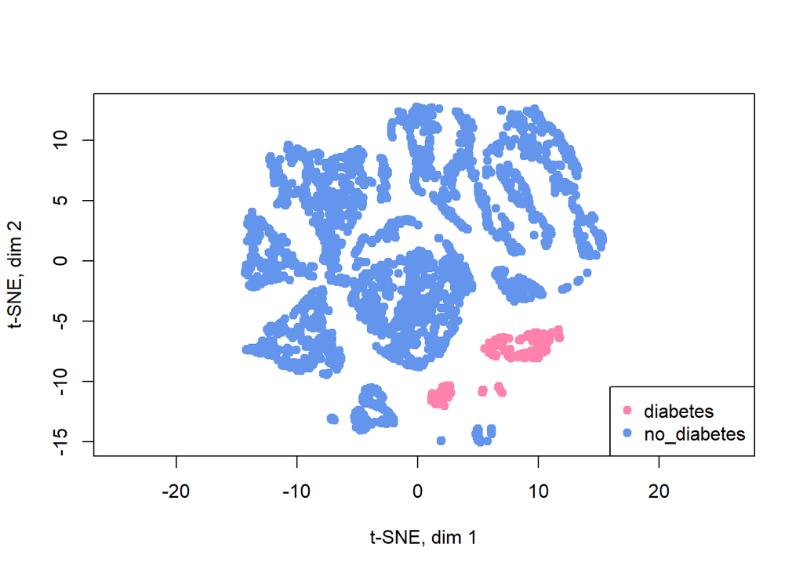

```r
par(mfrow = c(1, 1))
plot(x = myRtsne_result_df$V1,
     y = myRtsne_result_df$V2, pch = 19, asp = 1,
     xlab = "t-SNE, dim 1", ylab = "t-SNE, dim 2",
     col = myRtsne_result_df$color)
legend(x = "bottomright", pch = 19, legend = c("diabetes", "no_diabetes"),
       col = c("palevioletred1", "cornflowerblue"))
```

Unlike with cMDS mapping, the mapping by t-SNE produced several tight and smaller clusters within the “no_diabetes” cluster. The same is applicable to the “diabetes” cluster. Note that both the smaller and larger clusters are much tighter than those produced by cMDS. This is because t-SNE attempts to preserve local distances (i.e., within a cluster) at the expence of global distances (i.e., between clusters), which is different from cMDS. Thereby, t-SNE is much less affected by a large number of data points in the dataset.

The limitation of t-SNE is that this method is sensitive to hyperparameters “perplexity” and “max_iter”. The former roughly corresponds to the anticipated number of “neighbors” (that is, data points within a cluster). The latter hyperparameter defines the number of iterations to repeat the process when t-SNE looks for an optimal approximation of the original dataset (please see my other tutorial for details). There some general recommendations for both. The original publication (https://jmlr.org/papers/v9/vandermaaten08a.html) recommends the optimal “perplexity” value between 5 and 50. A follow-up publication (https://www.nature.com/articles/s41467-019-13056-x) set the “perplexity” to 1% of the dataset (in our case: 40) in order to improve the mapping of the global dataset structure. The latter publication also set the very minimal number of iterations above 200 or (preferrably) to 1/12 of the size of the dataset (in our case: 333). Please try to use the “perplexity” at 5, 15, and 30, or increase the number of iterations up to 1000, to see how the mapping will change.

While the preservation of the local dataset structure is a distinct advantage of t-SNE over cMDS, the volatility associated with even the slightest changes of the aforementioned hyperparameters make this method less predictable (and often, less plausible). Still, t-SNE, and especially the newer method “UMAP”, are very popular methods to map the transcriptome findings, including the results of single-cell sequencing.